# Hands-on Exercise 5e: Treemap Visualisation with R

Author

Andy Tai

Published

May 10, 2026

Modified

May 10, 2026

## 1 Overview

A treemap is a visualisation method that represents proportions using the size of rectangular areas. It is useful for displaying large amounts of data and organising them hierarchically through categorical groupings.

In this hands-on exercise, we will learn to:

- Transform transaction data into a treemap structure using functions from `dplyr`,
- Create static treemaps using `treemap`,
- Build interactive treemaps using `d3treeR`.

## 2 Getting Started

**Install libraries**

For this exercise, the `treemap`, `treemapify`, and `tidyverse` packages will be used.

```r
pacman::p_load(treemap, treemapify, tidyverse)
```

**Import Data**

In this hands-on exercise, REALIS2018.csv will be used. This dataset provides information of private property transaction records in 2018, and was extracted from [REALIS](https://eservice.ura.gov.sg/reis/index) portal of Urban Redevelopment Authority (URA).

```r
library(janitor)

data <- read_csv("data/realis2018.csv") %>%
  clean_names()

glimpse(data)
```

```
Rows: 23,205
Columns: 20
$ project_name                <chr> "ADANA @ THOMSON", "ALANA", "ALANA", "ALAN…
$ address                     <chr> "8 Old Upper Thomson Road  #05-03", "156 S…
$ no_of_units                 <dbl> 1, 1, 1, 1, 1, 1, 1, 1, 1, 1, 1, 1, 1, 1, …
$ area_sqm                    <dbl> 52, 284, 256, 256, 277, 285, 234, 155, 115…
$ type_of_area                <chr> "Strata", "Strata", "Strata", "Strata", "S…
$ transacted_price            <dbl> 888888, 2530000, 2390863, 2450000, 1980000…
$ nett_price                  <chr> "-", "-", "2382517", "2441654", "-", "-", …
$ unit_price_psm              <dbl> 17094, 8908, 9307, 9538, 7148, 6947, 14763…
$ unit_price_psf              <dbl> 1588, 828, 865, 886, 664, 645, 1371, 1499,…
$ sale_date                   <chr> "4-Jul-18", "5-Oct-18", "9-Jun-18", "14-Ma…
$ property_type               <chr> "Apartment", "Terrace House", "Terrace Hou…
$ tenure                      <chr> "Freehold", "103 Yrs From 12/08/2013", "10…
$ completion_date             <chr> "2018", "2018", "2018", "2018", "2008", "2…
$ type_of_sale                <chr> "New Sale", "Sub Sale", "New Sale", "New S…
$ purchaser_address_indicator <chr> "Private", "Private", "HDB", "N.A", "Priva…
$ postal_district             <dbl> 20, 28, 28, 28, 26, 26, 26, 26, 26, 26, 26…
$ postal_sector               <dbl> 57, 80, 80, 80, 78, 78, 78, 78, 78, 78, 78…
$ postal_code                 <dbl> 573868, 804555, 804529, 804540, 786300, 78…
$ planning_region             <chr> "North East Region", "North East Region", …
$ planning_area               <chr> "Ang Mo Kio", "Ang Mo Kio", "Ang Mo Kio", …
```

**Process Data**

The raw dataset is in transaction-record form — too granular for treemap visualisation. We use `group_by()` and `summarise()` from `dplyr` to aggregate it into a suitable format by:

- Grouping records by *Project Name*, *Planning Region*, *Planning Area*, *Property Type* and *Type of Sale*
- Computing *Total Unit Sold*, *Total Area*, *Median Unit Price* and *Median Transacted Price* for each group

Key functions used:

- `group_by()` — splits the dataframe into groups based on specified variables. All subsequent operations are applied within each group
- `summarise()` — computes summary statistics for each group, collapsing multiple rows into one per group

```r
realis2018_summarised <- data %>%
  group_by(project_name, planning_region,
           planning_area, property_type,
           type_of_sale) %>%
  summarise(
    total_unit_sold          = sum(no_of_units,       na.rm = TRUE),
    total_area               = sum(area_sqm,          na.rm = TRUE),
    median_unit_price_psm    = median(unit_price_psm, na.rm = TRUE),
    median_transacted_price  = median(transacted_price, na.rm = TRUE),
    .groups = "drop"
  )
```

## 3 Static Treemap - using treemap package

```r
realis2018_selected <- realis2018_summarised %>%
  filter(property_type == "Condominium",
         type_of_sale  == "Resale")
```

**(a) Basic**

The code chunk below designed a treemap by using three core arguments of `treemap()`, namely: `index`, `vSize` and `vColor`.

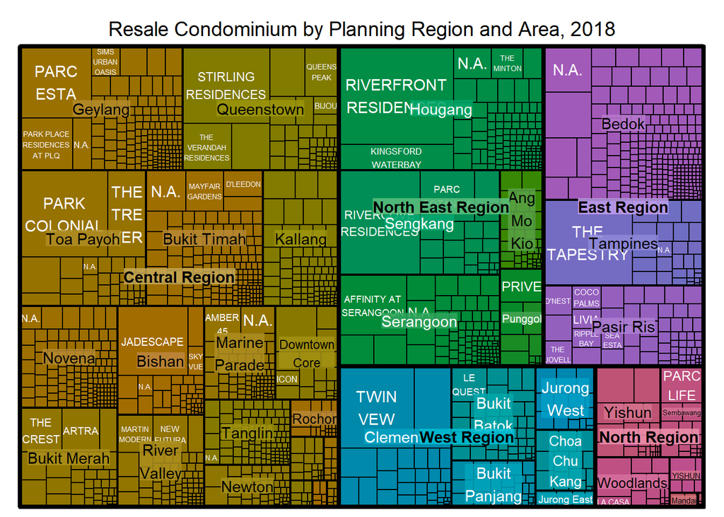

```r
treemap(realis2018_summarised,
        index  = c("planning_region", "planning_area", "project_name"),
        vSize  = "total_unit_sold",
        vColor = "median_unit_price_psm",
        title  = "Resale Condominium by Planning Region and Area, 2018",
        title.legend = "Median Unit Price (S$ per sq. m)"
        )
```

- `index`: List of categorical variables defining the hierarchy. At least two columns are required. The first column represents the highest aggregation level, followed by lower levels.
- `vSize`: Quantitative variable used to determine rectangle sizes. Values must be non-negative.

**(b) vColor**

In a well-designed treemap, colour intensity represents data values, such as median unit prices.

In `treemap()`, `vColor` works with type to control rectangle colours. If `type` is not specified, the default is `type = "index"`, which colours by hierarchy levels. In the code below, type = “value” is used instead.

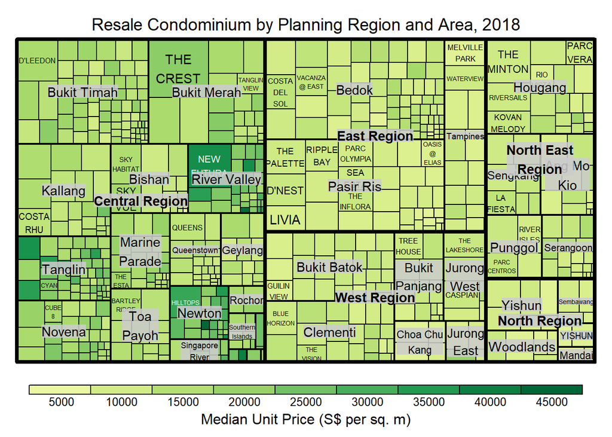

```r
treemap(realis2018_selected,
        index  = c("planning_region", "planning_area", "project_name"),
        vSize  = "total_unit_sold",
        vColor = "median_unit_price_psm",
        type   = "value",
        title  = "Resale Condominium by Planning Region and Area, 2018",
        title.legend = "Median Unit Price (S$ per sq. m)"
        )
```

**(c) type**

`mapping` and `palette` control colour mapping in a treemap.

- `"value"` treats the palette as diverging, mapping 0 to the middle colour, negative values to one end, and positive values to the other.
- `"manual"` maps the minimum and maximum values directly to the palette ends, with the midpoint mapped to the middle colour.

**(1) value**

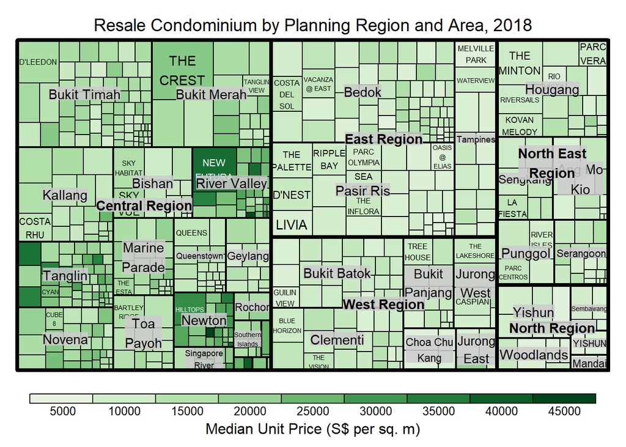

```r
treemap(realis2018_selected,
        index  = c("planning_region", "planning_area", "project_name"),
        vSize  = "total_unit_sold",
        vColor = "median_unit_price_psm",
        type   = "value",
        palette = "PRGn",                              #<< purple-green diverging
        title  = "Resale Condominium by Planning Region and Area, 2018",
        title.legend = "Median Unit Price (S$ per sq. m)"
        )
```

**(2) manual**

Diverging palettes such as `“RdYlBu”` are best used when data contains both positive and negative values. For data with only positive or only negative values, a single-colour palette such as `“Blues”` is more suitable.

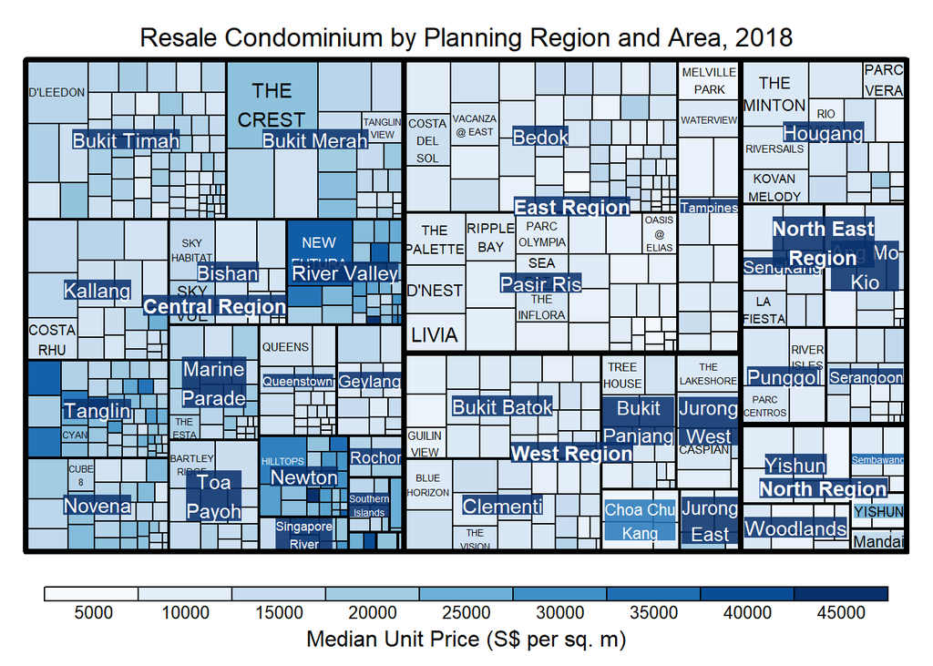

```r
treemap(realis2018_selected,
        index   = c("planning_region", "planning_area", "project_name"),
        vSize   = "total_unit_sold",
        vColor  = "median_unit_price_psm",
        type    = "manual",
        palette = "Blues",                             #<< single colour, light to dark
        title   = "Resale Condominium by Planning Region and Area, 2018",
        title.legend = "Median Unit Price (S$ per sq. m)"
        )
```

**(d) algorithm**

treemap() supports two popular treemap layouts, namely: “squarified” and “pivotSize”.

**Note**

[figure not shown]

‘squarified’ vs ‘pivotSize’

| Feature | `squarified` | `pivotSize` |
| --- | --- | --- |
| **Approach** | Makes rectangles as square as possible | Uses a pivot element to split remaining space |
| **Aspect ratio** | Better — rectangles closer to square | Can produce more elongated rectangles |
| **Order preservation** | Less strict — sacrifices order for shape | Better preserves input order of items |
| **Readability** | Easier to compare sizes visually | Easier to find specific items by position |
| **Best for** | When shape comparison matters | When order/position matters |

**(1) squarified**

- Rectangles are more **square-shaped** — easier to compare sizes at a glance
- Central Region dominates visually and is immediately obvious
- However, **positions shift** — similar areas are not grouped consistently

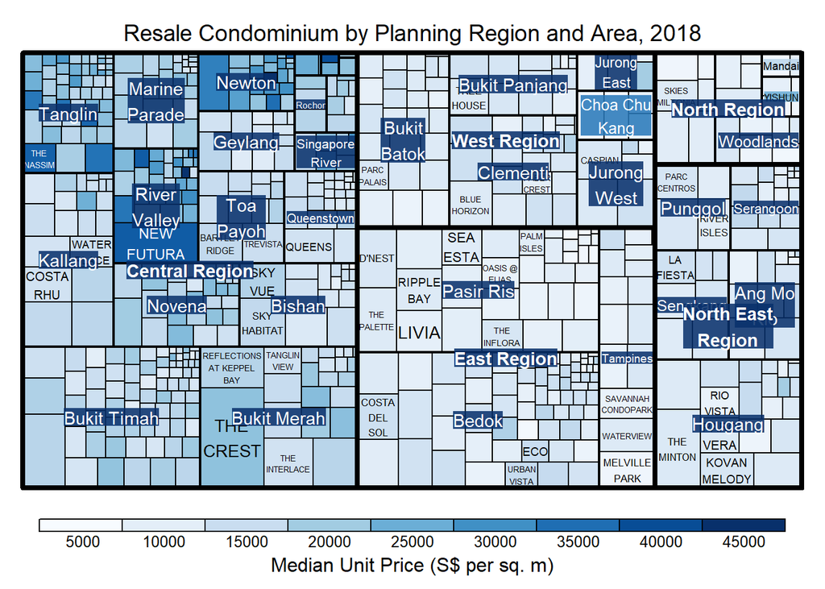

```r
treemap(realis2018_selected,
        index     = c("planning_region", "planning_area", "project_name"),
        vSize     = "total_unit_sold",
        vColor    = "median_unit_price_psm",
        type      = "manual",
        palette   = "Blues",
        algorithm = "squarified",
        title     = "Resale Condominium by Planning Region and Area, 2018",
        title.legend = "Median Unit Price (S$ per sq. m)"
        )
```

**(2) pivotSize**

- Rectangles are more **elongated** — harder to compare sizes
- Layout is more **stable and ordered** — planning regions stay in consistent positions
- Easier to **locate specific areas** since their positions are more predictable

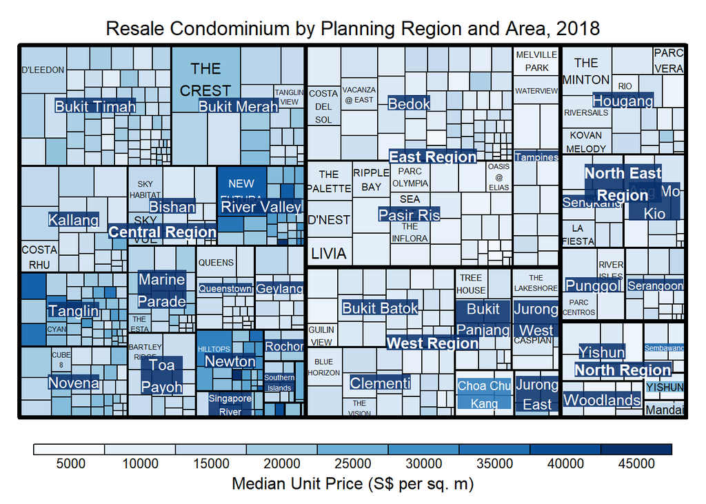

```r
treemap(realis2018_selected,
        index     = c("planning_region", "planning_area", "project_name"),
        vSize     = "total_unit_sold",
        vColor    = "median_unit_price_psm",
        type      = "manual",
        palette   = "Blues",
        algorithm = "pivotSize",
        title     = "Resale Condominium by Planning Region and Area, 2018",
        title.legend = "Median Unit Price (S$ per sq. m)"
        )
```

**(e) sortID**

`sortID` specifies the variable used to determine the order in which rectangles are placed within each group — here, rectangles are arranged by `median_transacted_price`.

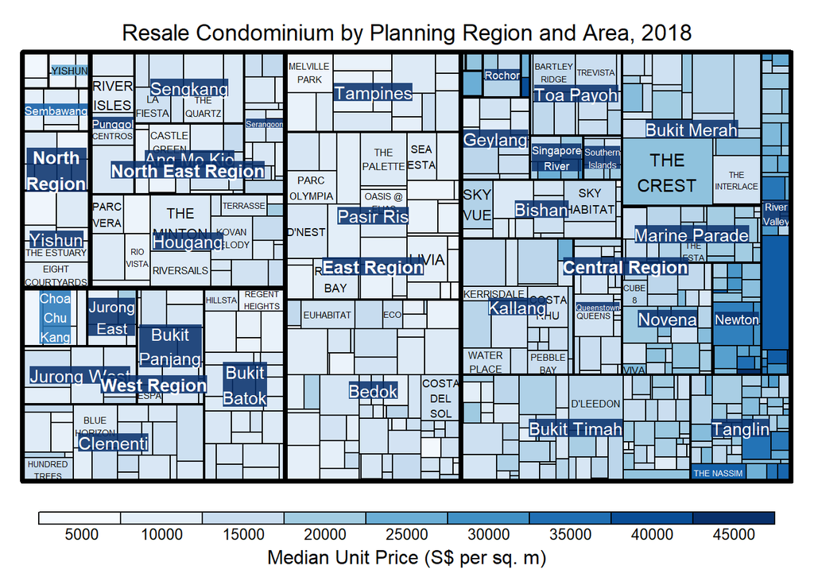

```r
treemap(realis2018_selected,
        index     = c("planning_region", "planning_area", "project_name"),
        vSize     = "total_unit_sold",
        vColor    = "median_unit_price_psm",
        type      = "manual",
        palette   = "Blues",
        algorithm = "pivotSize",
        sortID    = "median_transacted_price",
        title     = "Resale Condominium by Planning Region and Area, 2018",
        title.legend = "Median Unit Price (S$ per sq. m)"
        )
```

## 4 Static Treemap - using treemapify package

**treemapify** is a R package specially developed to draw treemaps in **ggplot2**.

**step 1 - basic treemap**

The first step is to plot the simple treemap with the help of ggplot() and geom_treemap() functions.

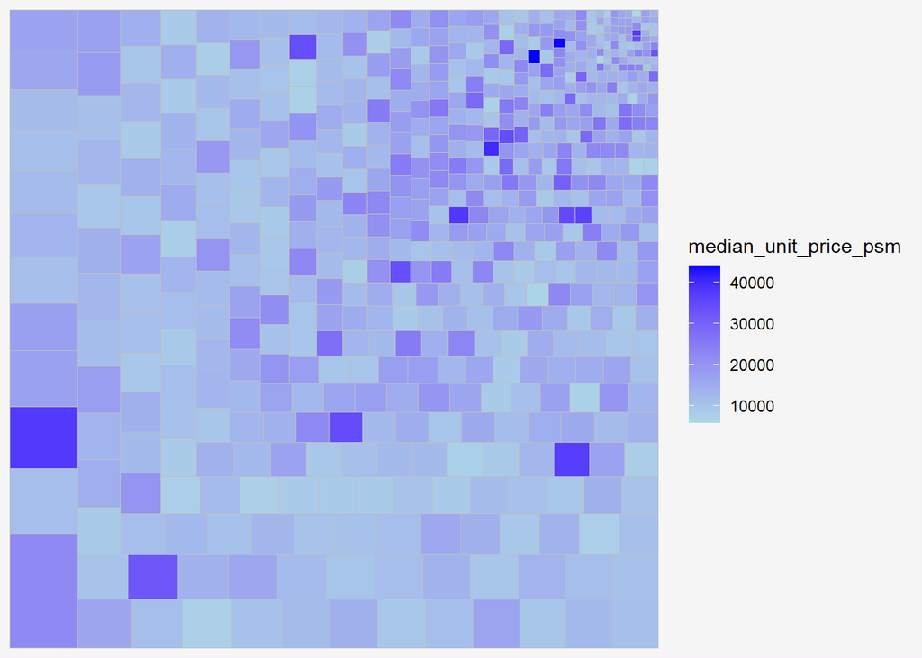

```r
ggplot(data = realis2018_selected,
       aes(area = total_unit_sold,
           fill = median_unit_price_psm)) +
  geom_treemap(layout = "scol",
                start  = "bottomleft") +
  scale_fill_gradient(low = "light blue", high = "blue") +
    theme(
      plot.title = element_text(hjust=0, family = "Bold"),
      plot.background = element_rect(fill = "#f5f5f5", color = "#f5f2f5"),
      legend.background = element_rect(fill="#f5f5f5"),
      panel.background = element_rect(fill="#f5f5f5"))
```

**step 2 - group region**

Next step is to group by planning region. This can be can be plotted by with the `subgroup()` argument in aesthetics (aes) of the plot in **ggplot()** function as follows

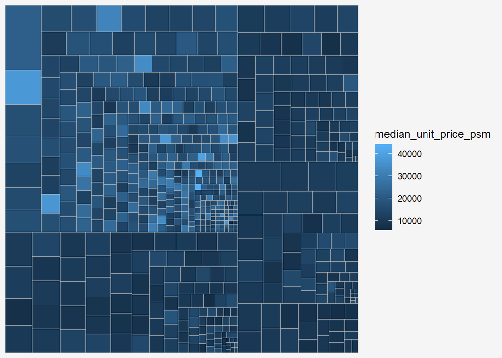

```r
ggplot(data = realis2018_selected,
       aes(area     = total_unit_sold,
           fill     = median_unit_price_psm,
           subgroup = planning_region)) +
      geom_treemap(start = "topleft") +
      theme(
      plot.title = element_text(hjust=0, family = "bold"),
      plot.background = element_rect(fill = "#f5f5f5", color = "#f5f2f5"),
      legend.background = element_rect(fill="#f5f5f5"),
      panel.background = element_rect(fill="#f5f5f5"))
```

**step 3 - boundary line**

Lastly, add a boundary line and title.

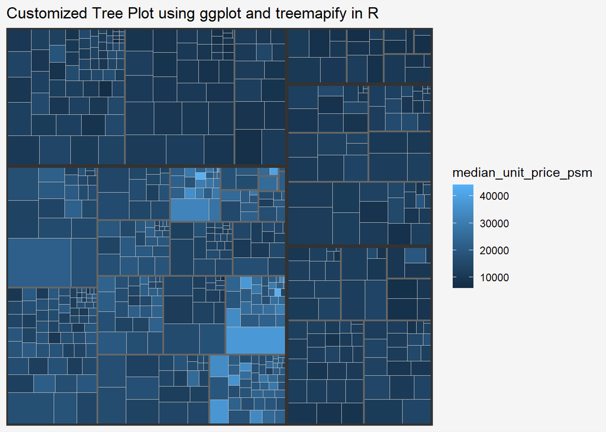

```r
ggplot(data = realis2018_selected,
       aes(area      = total_unit_sold,
           fill      = median_unit_price_psm,
           subgroup  = planning_region,
           subgroup2 = planning_area,
           label     = planning_region)) +
  geom_treemap() +
  geom_treemap_subgroup2_border(colour = "gray40",
                                size   = 2) +
  geom_treemap_subgroup_border(colour = "gray20") +
  #geom_treemap_text(place = "centre", size = 12, color = "white") +
  labs(title = "Customized Tree Plot using ggplot and treemapify in R") +
  theme_bw() +
    theme(
      plot.title = element_text(hjust=0, family = "bold"),
      plot.background = element_rect(fill = "#f5f5f5", color = "#f5f2f5"),
      legend.background = element_rect(fill="#f5f5f5"),
      panel.background = element_rect(fill="#f5f5f5"))
```

## 5 Interactive Treemap - using d3treeR package

We need to install the basic libraries.

```r
library(devtools)
library(d3treeR)
library(widgetframe)
```

**step 1 - basic treemap**

`treemap()` is used to build a treemap by using selected variables in condominium data.frame. The treemap created is save as object called **tm**.

[figure not shown]

```r
tm <- treemap(realis2018_summarised,
        index  = c("planning_region", "planning_area"),
        vSize  = "total_unit_sold",
        vColor = "median_unit_price_psm",
        type   = "value",
        title  = "Private Residential Property Sold, 2018",
        title.legend = "Median Unit Price (S$ per sq. m)"
        )
```

**step 2 - interactivity with d3tree()**

The second step is to use `d3tree()` is used to build an interactive treemap. The argument of `rootname` parameter becomes the title of the plot

[interactive chart not shown]

## 6 References

- Kam, T.S. (2023). [Treemap Visualisation with R](https://r4va.netlify.app/chap16).